# Classify ALS diagnosis from white matter features

This example demonstrates classification, a machine learning task in which a model is constructed and fit to accurately discriminate between different classes of subjects. In this case, participants with amyotrophic lateral sclerosis (ALS) and healthy control. We use the dataset from ([Sarica et al, 2017](https://pmc.ncbi.nlm.nih.gov/articles/PMC6867092/)), which contains tractometry features from 24 patients with ALS and 24 demographically matched control subjects. We will use the sparse group lasso (SGL) algorithm implemented in AFQ-Insight, as also described in [Richie-Halford et al. 2021](https://journals.plos.org/ploscompbiol/article?id=10.1371/journal.pcbi.1009136).

```python
import os.path as op
from paths import afq_home

import matplotlib.pyplot as plt
import numpy as np
from groupyr.decomposition import GroupPCA
from sklearn.impute import SimpleImputer
from sklearn.model_selection import cross_validate

from afqinsight import load_afq_data, make_afq_classifier_pipeline
```

## Load the data from Sarica et al.

The data is read into an AFQData object, which manages the division of subject information and outputs of pyAFQ (in the `nodes.csv` file) and merges between them.

```python
afqdata = load_afq_data(op.join(afq_home, "afq-insight/sarica/nodes.csv"),
                        op.join(afq_home, "afq-insight/sarica/subjects.csv"),
                        dwi_metrics=["fa", "md"],
                        target_cols=["class"],
                        label_encode_cols=["class"])
```

## Examine the data

`afqdata` is an `AFQDataset` object, with properties corresponding to the tractometry features and phenotypic targets.

```python
X = afqdata.X
y = afqdata.y.astype(float)  # SGL expects float targets
groups = afqdata.groups
feature_names = afqdata.feature_names
group_names = afqdata.group_names
subjects = afqdata.subjects
```

## Reduce data dimensionality

Here we reduce computation time by taking the first 10 principal components of each feature group and performing SGL logistic regression on those components. If you want to train an SGL model without group PCA, set `do_group_pca = False`. This will increase the number of features by an order of magnitude and slow down execution time.

```python
do_group_pca = True

if do_group_pca:
    n_components = 10

    # The next three lines retrieve the group structure of the group-wise PCA
    # and store it in ``groups_pca``. We do not use the imputer or GroupPCA transformer
    # for anything else
    imputer = SimpleImputer(strategy="median")
    gpca = GroupPCA(n_components=n_components, groups=groups)
    groups_pca = gpca.fit(imputer.fit_transform(X)).groups_out_

    transformer = GroupPCA
    transformer_kwargs = {"groups": groups, "n_components": n_components}
else:
    transformer = False
    transformer_kwargs = None
```

## Create the classification pipeline

The core computational machinery is a pipeline. These operate as scikit-learn compatible pipelines, so we can pass them to scikit-learn functions. There are many options that need to be set to configure the pipeline object.

```python
pipe = make_afq_classifier_pipeline(
    imputer_kwargs={"strategy": "median"},  # Use median imputation
    use_cv_estimator=True,  # Automatically determine the best hyperparameters
    feature_transformer=transformer,  # See note above about group PCA
    feature_transformer_kwargs=transformer_kwargs,
    scaler="standard",  # Standard scale the features before regression
    groups=(
        groups_pca if do_group_pca else groups
    ),  # SGL will use the original feature groups or the PCA feature groups depending on the choice above # noqa E501
    verbose=0,  # Be quiet!
    pipeline_verbosity=False,  # No really, be quiet!
    tuning_strategy="bayes",  # Use BayesSearchCV to determine optimal hyperparameters
    n_bayes_iter=20,  # Consider only this many points in hyperparameter space
    cv=3,  # Use three CV splits to evaluate each hyperparameter combination
    l1_ratio=[0.0, 1.0],  # Explore the entire range of ``l1_ratio``
    eps=5e-2,  # This is the ratio of the smallest to largest ``alpha`` value
    tol=1e-2,  # Set a lenient convergence tolerance just for this example
)
```

## Fit and cross-validate

The `pipe` object is a scikit-learn pipeline and can be used in other scikit-learn functions. Here, the generic `cross_validate` function.

```python
scores = cross_validate(
    pipe, X, y, cv=5, return_train_score=True, return_estimator=True
)
```

## Display results

Finally, we display the results, including both the training and test scores, as well as a visualization of the model coefficients: which tracts contributed the most to this classification.

```
Mean train score: 1.000
Mean test score:  0.791
Mean fit time:     3.22s
Mean score time:   0.00s
```

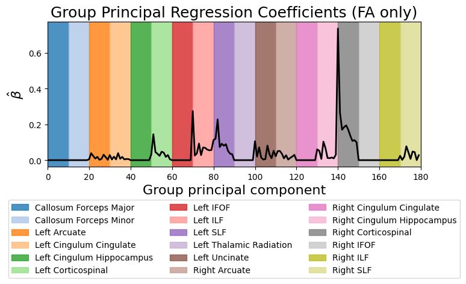

```python
print(f"Mean train score: {np.mean(scores['train_score']):5.3f}")
print(f"Mean test score:  {np.mean(scores['test_score']):5.3f}")
print(f"Mean fit time:    {np.mean(scores['fit_time']):5.2f}s")
print(f"Mean score time:  {np.mean(scores['score_time']):5.2f}s")

mean_coefs = np.mean(
    np.abs([est.named_steps["estimate"].coef_ for est in scores["estimator"]]), axis=0
)

fig, ax = plt.subplots(1, 1, figsize=(8, 5))
_ = ax.plot(mean_coefs[:180], color="black", lw=2)
_ = ax.set_xlim(0, 180)

colors = plt.get_cmap("tab20").colors
for grp, grp_name, color in zip(groups_pca[:18], group_names, colors):
    _ = ax.axvspan(grp.min(), grp.max() + 1, color=color, alpha=0.8, label=grp_name[1])

box = ax.get_position()
_ = ax.set_position(
    [box.x0, box.y0 + box.height * 0.375, box.width, box.height * 0.625]
)

_ = ax.legend(loc="upper center", bbox_to_anchor=(0.5, -0.2), ncol=3)
_ = ax.set_ylabel(r"$\hat{\beta}$", fontsize=16)
_ = ax.set_xlabel("Group principal component", fontsize=16)
_ = ax.set_title("Group Principal Regression Coefficients (FA only)", fontsize=18)
```